# TASK 3

#Importing the libraries

```r
library(tidyverse)
library(DT)
library(choroplethr)
library(choroplethrMaps)
```

#importing the dataset

```r
Superstore= read.csv("SampleSuperstore.csv")
```

#doing the slaes Analysis

#Statewise sales analysis

```r
Statewise_Sales= Superstore %>%
  group_by(State) %>%
  summarise(Total_Sales= sum(Sales)) %>%
  arrange(desc(Total_Sales))
datatable(Statewise_Sales)
```

|  | State | Total_Sales |
| --- | --- | --- |
| 1 | California | 457687.6315 |
| 2 | New York | 310876.271 |
| 3 | Texas | 170188.0458 |
| 4 | Washington | 138641.27 |
| 5 | Pennsylvania | 116511.914 |
| 6 | Florida | 89473.708 |
| 7 | Illinois | 80166.101 |
| 8 | Ohio | 78258.136 |
| 9 | Michigan | 76269.614 |
| 10 | Virginia | 70636.72 |

[output cut: 39 more lines]

#Plotting Statewise Sales Analysis

[figure not shown]

```r
ggplot(Statewise_Sales,aes(reorder(State,Total_Sales),Total_Sales,fill=State))+
  geom_col(width = 0.5, alpha = 0.5)+
  geom_point(size=3, color="black",alpha=0.07)+
  scale_x_discrete(labels = Statewise_Sales[order(Statewise_Sales$Total_Sales),]$State) +
  theme_classic()+
  coord_flip()+
  geom_text(aes(State,Total_Sales,label =Total_Sales))+
  labs(x = "State", y = "Total Sales", title = "Statewise Sales Analysis")+
  theme(axis.text = element_text(size = 10, face = "bold"), title  =  element_text(size = 16))+
  theme(legend.title = element_text(size=10),legend.text = element_text(size=10),legend.position="bottom")
```

#*Regionwise Sales Analysis

```r
Regionwise_Sales= Superstore %>%
  group_by(Region) %>%
  summarise(TotalS= sum(Sales)) %>%
  arrange(desc(TotalS))
datatable(Regionwise_Sales)
```

|  | Region | TotalS |
| --- | --- | --- |
| 1 | West | 725457.8245 |
| 2 | East | 678781.24 |
| 3 | Central | 501239.8908 |
| 4 | South | 391721.905 |

#Plotting Regionwise Sales Analysis

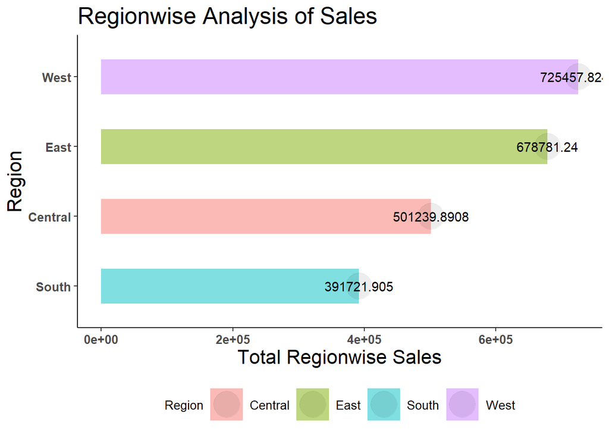

```r
ggplot(Regionwise_Sales,aes(reorder(Region,TotalS),TotalS,fill=Region))+
  geom_col(width = 0.5, alpha = 0.5)+
  geom_point(size=10, color="black",alpha=0.07)+
  scale_x_discrete(labels = Regionwise_Sales[order(Regionwise_Sales$TotalS),]$Region) +
  theme_classic()+
  coord_flip()+
  geom_text(aes(Region,TotalS,label =TotalS))+
  labs(x = "Region", y = "Total Regionwise Sales", title = "Regionwise Analysis of Sales")+
  theme(axis.text = element_text(size = 10, face = "bold"), title  =  element_text(size = 16))+
  theme(legend.title = element_text(size=10),legend.text = element_text(size=10),legend.position="bottom")
```

#Geographic Plots of Statewise Sales Analysis

```r
GSPlot= Superstore %>%
  group_by(State) %>%
  summarise(Total_Sales= sum(Sales)) %>%
  arrange(desc(Total_Sales))
datatable(GSPlot)
```

|  | State | Total_Sales |
| --- | --- | --- |
| 1 | California | 457687.6315 |
| 2 | New York | 310876.271 |
| 3 | Texas | 170188.0458 |
| 4 | Washington | 138641.27 |
| 5 | Pennsylvania | 116511.914 |
| 6 | Florida | 89473.708 |
| 7 | Illinois | 80166.101 |
| 8 | Ohio | 78258.136 |
| 9 | Michigan | 76269.614 |
| 10 | Virginia | 70636.72 |

[output cut: 39 more lines]

#Converting into a Geographic Plot

```r
colnames(GSPlot)= c('region', 'value')
GSPlot$region= tolower(GSPlot$region)
```

#we use here library(choroplethr) and library(choroplethrMaps) for map

#Plots of Statewise Sales Analysis

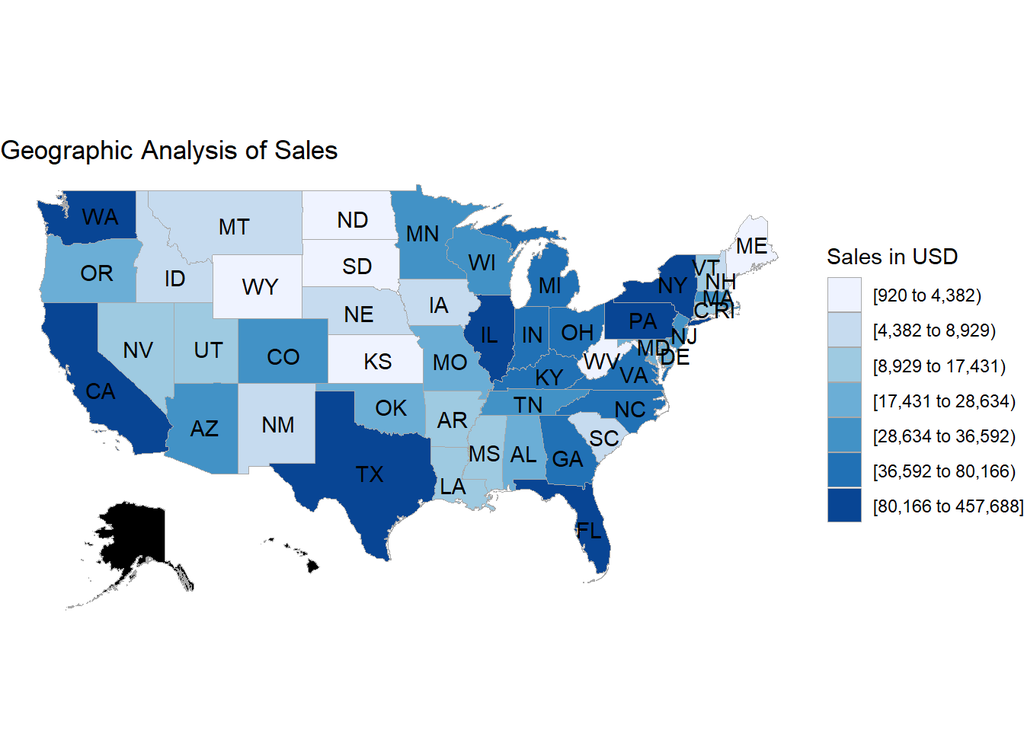

```r
state_choropleth(GSPlot,title= "Geographic Analysis of Sales",legend="Sales in USD")
```

##OBSERVATIONS

#1. State of California recorded the highest Sales, around 450,000 USD.

#2. New York has the second highest Sales, around 300,000 USD.

#4. North Dakota records the least Sales, around 1000 USD.

#5. We can see from the geographic and regionwise plots that the company’s Sales are mostly concentrated on the East and West Coast of America.

#Profit Analysis

#Statewise Profit Analysis

```r
Statewise_Profit= Superstore %>%
  group_by(State) %>%
  summarise(Total_Profit= sum(Profit)) %>%
  arrange(desc(Total_Profit))
datatable(Statewise_Profit)
```

|  | State | Total_Profit |
| --- | --- | --- |
| 1 | California | 76381.3871 |
| 2 | New York | 74038.5486 |
| 3 | Washington | 33402.6517 |
| 4 | Michigan | 24463.1876 |
| 5 | Virginia | 18597.9504 |
| 6 | Indiana | 18382.9363 |
| 7 | Georgia | 16250.0433 |
| 8 | Kentucky | 11199.6966 |
| 9 | Minnesota | 10823.1874 |
| 10 | Delaware | 9977.3748 |

[output cut: 39 more lines]

#Plotting Statewise Profit Analysis

[figure not shown]

```r
ggplot(Statewise_Profit, aes(x=State,y=Total_Profit,fill= State)) +
  geom_col(width = 0.7, alpha = 0.5)+
  geom_point(size=3, color="black",alpha=0.07)+
  scale_x_discrete(labels = Statewise_Profit[order(Statewise_Profit$Total_Profit),]$State) +
  coord_flip()+
  geom_text(aes(State,Total_Profit,label =Total_Profit))+
  labs(x = "State", y = "Total Profit", title = "Statewise Profit Analysis")+
  theme(axis.text = element_text(size = 10, face = "bold"), title  =  element_text(size = 16))+
  theme(legend.title = element_text(size=10),legend.text = element_text(size=10),legend.position="bottom")
```

#Regionwise Profit Analysis

```r
Regionwise_Profit= Superstore %>%
  group_by(Region) %>%
  summarise(TotalP= sum(Profit)) %>%
  arrange(desc(TotalP))
datatable(Regionwise_Profit)
```

|  | Region | TotalP |
| --- | --- | --- |
| 1 | West | 108418.4489 |
| 2 | East | 91522.78 |
| 3 | South | 46749.4303 |
| 4 | Central | 39706.3625 |

#Plotting Regionwise Profit Analysis

[figure not shown]

```r
ggplot(Regionwise_Profit, aes(x=Region,y=TotalP,fill= Region)) +
  geom_col(width = 0.7, alpha = 0.5)+
  geom_point(size=9, color="black",alpha=0.07)+
  scale_x_discrete(labels = Regionwise_Profit[order(Regionwise_Profit$TotalP),]$Region) +
  theme_classic()+
  coord_flip()+
  geom_text(aes(Region,TotalP,label =TotalP))+
  labs(x = "Region", y = "Total Profit", title = "Statewise Profit Analysis")+
  theme(axis.text = element_text(size = 10, face = "bold"), title  =  element_text(size = 16))+
  theme(legend.title = element_text(size=10),legend.text = element_text(size=10),legend.position="bottom")
```

```r
GPPlot= Superstore %>%
  group_by(State) %>%
  summarise(Total_Profit= sum(Profit)) %>%
  arrange(desc(Total_Profit))
datatable(GPPlot)
```

|  | State | Total_Profit |
| --- | --- | --- |
| 1 | California | 76381.3871 |
| 2 | New York | 74038.5486 |
| 3 | Washington | 33402.6517 |
| 4 | Michigan | 24463.1876 |
| 5 | Virginia | 18597.9504 |
| 6 | Indiana | 18382.9363 |
| 7 | Georgia | 16250.0433 |
| 8 | Kentucky | 11199.6966 |
| 9 | Minnesota | 10823.1874 |
| 10 | Delaware | 9977.3748 |

[output cut: 39 more lines]

#Converting into a Geographic Plot

```r
colnames(GPPlot)= c('region', 'value')
GPPlot$region= tolower(GPPlot$region)
```

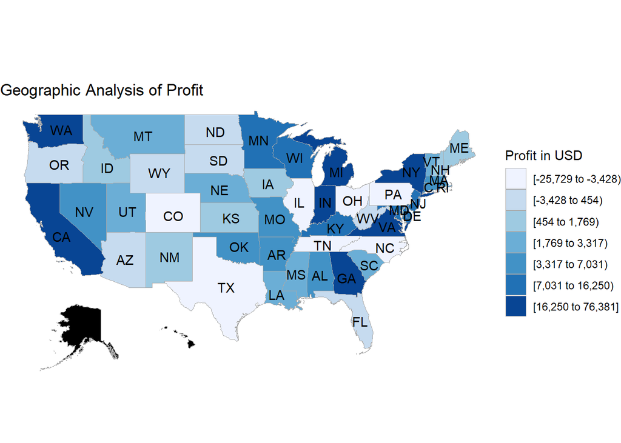

```r
state_choropleth(GPPlot,title= "Geographic Analysis of Profit",legend="Profit in USD")
```

#Observations

#1. From the Statewise Profit Analysis, the States of New York, California and Washington recorded the most profits.

#2. The State of Texas was the most unprofitable for the company causing severe losses.

#Doing some Statewise Profit/Sales Ratio Analysis

```r
Profit_to_Sales= Superstore %>%
  group_by(State) %>%
  summarise(Profit_Sales_Ratio= sum(Profit)/sum(Sales)) %>%
  arrange(desc(Profit_Sales_Ratio))
datatable(Profit_to_Sales)
```

|  | State | Profit_Sales_Ratio |
| --- | --- | --- |
| 1 | District of Columbia | 0.369836615451201 |
| 2 | Delaware | 0.363460337373382 |
| 3 | Minnesota | 0.362426180761239 |
| 4 | Maine | 0.357713867441147 |
| 5 | Arkansas | 0.34326446956833 |
| 6 | Indiana | 0.343251101290328 |
| 7 | Georgia | 0.330986154835114 |
| 8 | Montana | 0.328003765016052 |
| 9 | Rhode Island | 0.321974698023984 |
| 10 | Michigan | 0.320746183401426 |

[output cut: 39 more lines]

#Plotting Statewise Profit/Sales Ratio Analysis

[figure not shown]

```r
ggplot(Profit_to_Sales, aes(x=State,y=Profit_Sales_Ratio,fill= State)) +
  geom_bar(stat = "identity",width = 0.7, alpha = 0.5)+
  geom_point(size=3, color="black",alpha=0.07)+
  scale_x_discrete(labels = Profit_to_Sales[order(Profit_to_Sales$Profit_Sales_Ratio),]$State) +
  coord_flip()+
  geom_text(aes(State,Profit_Sales_Ratio,label =Profit_Sales_Ratio))+
  labs(x = "State", y = "Total Profit", title = "Statewise Profit Analysis")+
  theme(axis.text = element_text(size = 10, face = "bold"), title  =  element_text(size = 16))+
  theme(legend.title = element_text(size=10),legend.text = element_text(size=10),legend.position="bottom")
```

#Observations

#Some Profit to Sales Ratio Analysis showed that Ohio had the worst Profit-Sales Ratio

#We also understand that the states making the most profits, i.e, New York, California, and Washington do not show the maximum Profit-Sales ratio meaning that the company can improve its profits/sales in these states.

#Sales and Profit Analysis Segmentwise

```r
Profit_each_segment= Superstore %>%
  group_by(Segment) %>%
  summarise(Ratio= sum(Profit)/sum(Sales))%>%
  arrange(desc(Ratio))
datatable(Profit_each_segment)
```

|  | Segment | Ratio |
| --- | --- | --- |
| 1 | Home Office | 0.140342689703343 |
| 2 | Corporate | 0.130255055218674 |
| 3 | Consumer | 0.115480501014918 |

#plotting Profit/Sales Ratio Plots for each segment

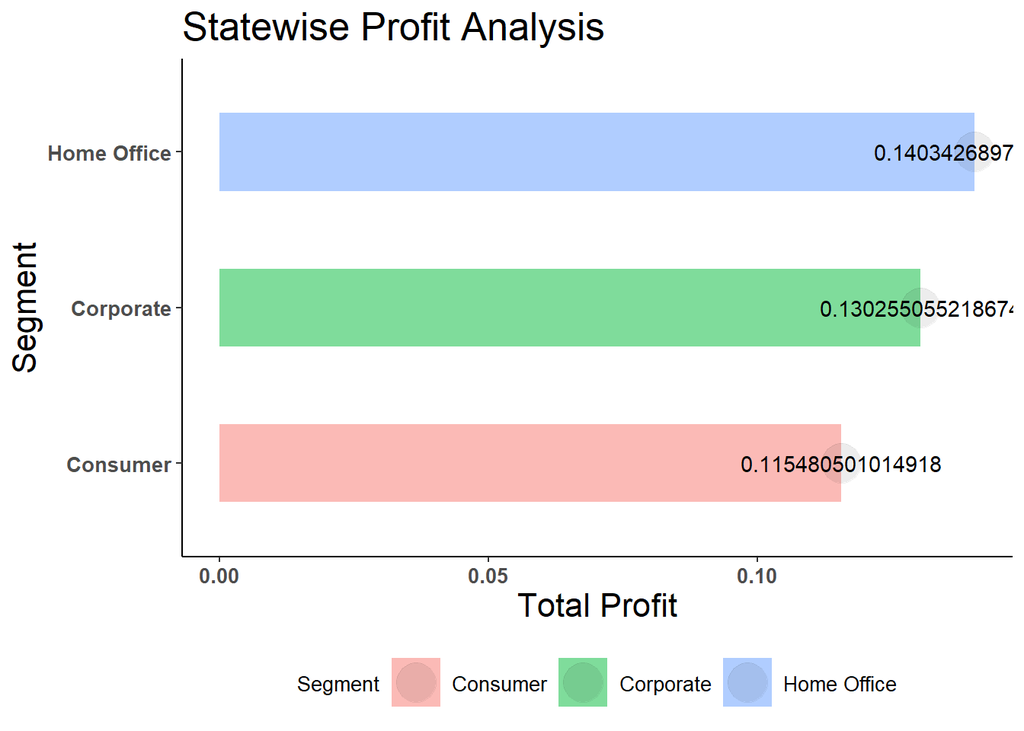

```r
ggplot(Profit_each_segment, aes(x=Segment,y=Ratio,fill= Segment)) +
  geom_col(width = 0.5, alpha = 0.5)+
  geom_point(size=9, color="black",alpha=0.07)+
  scale_x_discrete(labels = Profit_each_segment[order(Profit_each_segment$Ratio),]$Segment) +
  theme_classic()+
  coord_flip()+
  geom_text(aes(Segment,Ratio,label =Ratio))+
  labs(x = "Segment", y = "Total Profit", title = "Statewise Profit Analysis")+
  theme(axis.text = element_text(size = 10, face = "bold"), title  =  element_text(size = 16))+
  theme(legend.title = element_text(size=10),legend.text = element_text(size=10),legend.position="bottom")
```

#Observations

#1. For the Home Office Segment the Profit/Sales Ratio is the highest.

#2. There is scope for the company to improve its Profit/Sales ratio in the Consumer and Corporate Segment.